# Analisis Perilaku Penyewaan Film: Genre, Aktor, dan Segmentasi Pelanggan di Database Sakila

HAFIIDH EKA SAGITA (M0724030)

2026-05-26

# 1 Pendahuluan

**📋 Konteks Analisis**  
Laporan ini mengeksplorasi *apa yang sesungguhnya mendorong perilaku penyewaan film* di toko rental DVD yang direpresentasikan oleh database **Sakila**. penelitian berfokus pada tiga dimensi utama secara bersamaan: preferensi **genre**, pengaruh **aktor**, dan karakter **pelanggan**. Ketiga dimensi tersebut dibuhungkan melalui entitas `film` sebagai jembatan data.

## 1.1 Latar Belakang

Database **Sakila** merupakan **sample database** resmi MySQL yang merepresentasikansistem manajemen toko penyewaan DVD. Database ini terdiri dari **16 tabel** yang mencakup data film, aktor, pelanggan, staf, toko, transaksi sewa, hingga pembayaran.

Dalam bisnis rental film, terdapat setidaknya tiga pola perilaku pelanggan yang secara intuitif berbeda:

1. **Genre Lover** : Pelanggan yang secara konsisten menyewa film dari genre favorit tertentu.
2. **Actor Fans** : Pelanggan yang mengikuti aktor tertentu sehingga menyewa film apapun yang dibintanginya.
3. **Film Enthusiast** : Pelanggan yang menyewa film lintas genre secara merata, menunjukkan kecintaan terhadap film secara umum.

## 1.2 Rumusan Masalah

Laporan ini menjawab tiga pertanyaan utama:

> 1. Genre apa yang paling menguntungkan & apakah volume sewa tinggi selalu berbanding lurus dengan revenue?
> 2. Apakah ada efek *“Star Power”* aktor terhadap jumlah dan nilai rental?
> 3. Bagaimana profil segmentasi pelanggan berdasarkan keragaman genre yang disewa?

# 2 Data & Metodologi

## 2.1 Koneksi ke Database Sakila

```r
con <- dbConnect(
  RMySQL::MySQL(),
  host     = "localhost",
  port     = 3306,
  dbname   = "sakila",
  user     = "root",
  password = "MySQL"
)
```

## 2.2 Gambaran Umum Dataset

```r
tabel_kunci <- c("film", "actor", "category", "customer", "rental", "payment", "inventory")

ringkasan <- map_dfr(tabel_kunci, function(t) {
  n <- dbGetQuery(con, paste0("SELECT COUNT(*) AS n FROM ", t))$n
  tibble(Tabel = t, "Jumlah Record" = n)
})
```

Ringkasan jumlah record tabel utama Sakila

| Tabel | Jumlah Record |
| --- | --- |
| film | 1000 |
| actor | 200 |
| category | 16 |
| customer | 599 |
| rental | 16044 |
| payment | 16044 |
| inventory | 4581 |

1.000Total Film

200Aktor

599Pelanggan

16.044Transaksi Sewa

16Genre

# 3 Analisis Tiga Dimensi

Bagian ini menelaah tiga dimensi utama yang membentuk perilaku penyewaan film: **profibilitas genre**, **pengaruh aktor (star power)**, dan **segmentasi pelanggan** berbasis indeks konsentrasi genre. Ketiga dimensi dianalisis secara terpisah kemudian disintesiskan untuk menghasilkan gambaran bisnis yang menyeluruh.

## 3.1 Dimensi 1 - Genre & Profitabilitas

Dimensi 01 ⋅ Genre

### 3.1.1 Pengambilan Data

```r
df_genre <- dbGetQuery(con, "
  SELECT
    c.name                        AS genre,
    COUNT(DISTINCT r.rental_id)   AS total_rental,
    SUM(p.amount)                 AS total_revenue,
    ROUND(SUM(p.amount) /
          COUNT(DISTINCT r.rental_id), 2) AS revenue_per_rental
  FROM category c
    JOIN film_category fc ON c.category_id = fc.category_id
    JOIN film f           ON fc.film_id     = f.film_id
    JOIN inventory i      ON f.film_id      = i.film_id
    JOIN rental r         ON i.inventory_id = r.inventory_id
    JOIN payment p        ON r.rental_id    = p.rental_id
  GROUP BY c.name
  ORDER BY total_revenue DESC
")
```

### 3.1.2 Volume vs Revenue per Genre

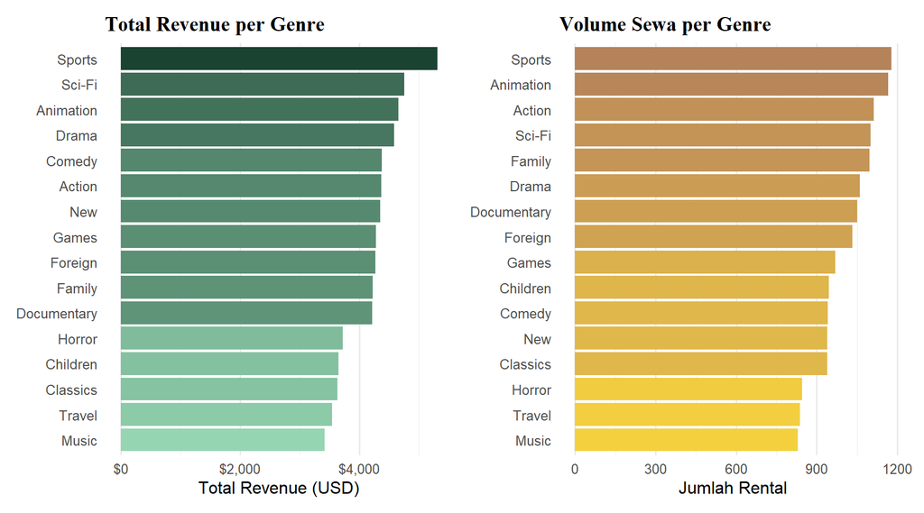

Perbandingan volume sewa dan total revenue per genre. Perbedaan urutan antar kedua grafik mengindikasikan variasi efisiensi revenue antar genre.

```r
p1 <- df_genre %>%
  mutate(genre = fct_reorder(genre, total_revenue)) %>%
  ggplot(aes(x = genre, y = total_revenue, fill = total_revenue)) +
  geom_col(show.legend = FALSE) +
  scale_fill_gradient(low = "#95d5b2", high = "#1b4332") +
  scale_y_continuous(labels = dollar_format(prefix = "$")) +
  coord_flip() +
  labs(title = "Total Revenue per Genre", x = NULL, y = "Total Revenue (USD)") +
  theme_minimal(base_size = 12) +
  theme(plot.title      = element_text(face = "bold", family = "serif"),
        panel.grid.major.y = element_blank())

p2 <- df_genre %>%
  mutate(genre = fct_reorder(genre, total_rental)) %>%
  ggplot(aes(x = genre, y = total_rental, fill = total_rental)) +
  geom_col(show.legend = FALSE) +
  scale_fill_gradient(low = "#f4d03f", high = "#b5835a") +
  coord_flip() +
  labs(title = "Volume Sewa per Genre", x = NULL, y = "Jumlah Rental") +
  theme_minimal(base_size = 12) +
  theme(plot.title      = element_text(face = "bold", family = "serif"),
        panel.grid.major.y = element_blank())

p1 + p2
```

### 3.1.3 Interpretasi

#### 🎯 Temuan Utama — Genre

**Sports** mendominasi secara konsisten, meraih posisi *pertama* pada kedua ranking (revenue *dan* volume), menjadikannya genre paling kuat secara keseluruhan. Namun ranking keduanya *tidak selalu identik*, yang mengungkap perbedaan efisiensi antar genre.

Genre **paling efisien** (revenue per rental tinggi relatif terhadap volume): **Comedy** berada di posisi #5 revenue namun hanya #11 volume, menghasilkan pendapatan besar dari jumlah sewa yang relatif sedikit. Genre **New** juga menunjukkan pola serupa (#7 revenue vs #12 volume).

Sebaliknya, genre **paling tidak efisien**: **Documentary** (#7 volume namun #11 revenue) dan **Family** (#5 volume namun #10 revenue), banyak disewa tetapi menghasilkan revenue per rental yang lebih rendah dari rata-rata.

## 3.2 Dimensi 2 — Pengaruh Aktor (*Star Power*)

Dimensi 02 ⋅ Aktor

### 3.2.1 Pengambilan Data

```r
df_aktor <- dbGetQuery(con, "
  SELECT
    CONCAT(a.first_name, ' ', a.last_name) AS aktor,
    COUNT(DISTINCT r.rental_id)            AS total_rental,
    SUM(p.amount)                          AS total_revenue,
    COUNT(DISTINCT fc.category_id)         AS jml_genre_dibintangi
  FROM actor a
    JOIN film_actor fa    ON a.actor_id     = fa.actor_id
    JOIN film f           ON fa.film_id     = f.film_id
    JOIN film_category fc ON f.film_id      = fc.film_id
    JOIN inventory i      ON f.film_id      = i.film_id
    JOIN rental r         ON i.inventory_id = r.inventory_id
    JOIN payment p        ON r.rental_id    = p.rental_id
  GROUP BY a.actor_id, a.first_name, a.last_name
  ORDER BY total_rental DESC
  LIMIT 20
")
```

### 3.2.2 Top 20 Aktor Berdasarkan Rental

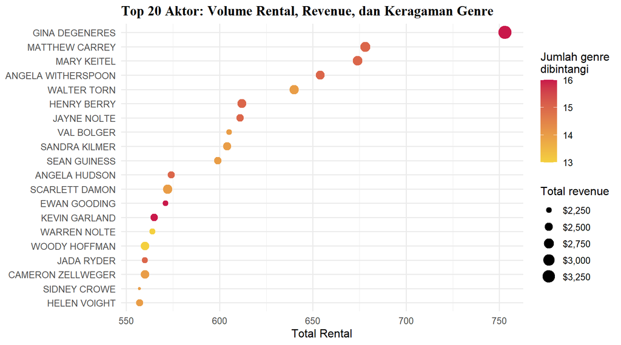

Top 20 aktor berdasarkan total rental. Warna menunjukkan keragaman genre yang dibintangi; ukuran titik menunjukkan total revenue.

```r
df_aktor %>%
  mutate(aktor = fct_reorder(aktor, total_rental)) %>%
  ggplot(aes(x     = aktor,
             y     = total_rental,
             color = jml_genre_dibintangi,
             size  = total_revenue)) +
  geom_point() +
  scale_color_gradient(low  = "#f4d03f", high = "#c9184a",
                       name = "Jumlah genre\ndibintangi") +
  scale_size_continuous(name   = "Total revenue",
                        labels = dollar_format(prefix = "$")) +
  coord_flip() +
  labs(title = "Top 20 Aktor: Volume Rental, Revenue, dan Keragaman Genre",
       x = NULL, y = "Total Rental") +
  theme_minimal(base_size = 12) +
  theme(plot.title = element_text(face = "bold", family = "serif"))
```

### 3.2.3 Interpretasi

#### 🎬 Temuan Utama — Aktor

**GINA DEGENERES** adalah aktor dengan *star power* paling dominan dengan meraih sekitar **750 rental**, jauh melampaui peringkat kedua (MATTHEW CARREY dan MARY KEITEL, ~675–680 rental). Selisih yang signifikan ini mengindikasikan adanya efek "superstar" yang nyata.

Dari sisi revenue, ukuran titik relatif seragam di kisaran **$2.250–$3.250**, menandakan bahwa gap jumlah rental yang besar belum tentu menghasilkan gap revenue yang proporsional yang kemungkinan karena harga sewa antar film relatif homogen.

## 3.3 Dimensi 3 — Segmentasi Pelanggan

Dimensi 03 ⋅ Pelanggan

### 3.3.1 Konsep: Herfindahl–Hirschman Index (HHI)

Untuk mengukur seberapa “terfokus” seorang pelanggan pada genre tertentu, digunakan **Herfindahl–Hirschman Index (HHI)** yang didefinisikan sebagai:

$$HHI_i = \sum_{g=1}^{G}
s_{ig}^2$$

di mana:

- $HHI_i$ = indeks konsentrasi genre pelanggan ke-$i$
- $G$ = jumlah total genre yang tersedia (16 genre)
- $s_{ig}$ = proporsi penyewaan pelanggan $i$ pada genre $g$:

$$s_{ig} =
\frac{n_{ig}}{\displaystyle\sum_{g'=1}^{G} n_{ig'}}$$

dengan $n_{ig}$ adalah jumlah film genre $g$ yang disewa pelanggan $i$.

Nilai HHI teoritis berkisar antara $\frac{1}{G} = \frac{1}{16} \approx 0{,}0625$ (distribusi sempurna merata) hingga $1$ (hanya 1 genre). Klasifikasi segmen:

| Rentang HHI | Segmen | Deskripsi |
| --- | --- | --- |
| $HHI \geq 0{,}6$ | Genre Lover | Sangat terfokus pada 1–2 genre |
| $0{,}3 \leq HHI < 0{,}6$ | Mixed Watcher | Preferensi genre tertentu |
| $HHI < 0{,}3$ | Film Enthusiast | Menyewa merata lintas genre |

### 3.3.2 Pengambilan Data

```r
# Langkah 1: jumlah sewa per pelanggan per genre
df_customer_genre <- dbGetQuery(con, "
  SELECT
    r.customer_id,
    c.name   AS genre,
    COUNT(*) AS n_rental
  FROM rental r
    JOIN inventory i      ON r.inventory_id  = i.inventory_id
    JOIN film_category fc ON i.film_id        = fc.film_id
    JOIN category c       ON fc.category_id   = c.category_id
  GROUP BY r.customer_id, c.name
")

# Langkah 2: hitung HHI per pelanggan di R
df_hhi <- df_customer_genre %>%
  group_by(customer_id) %>%
  mutate(
    total    = sum(n_rental),
    proporsi = n_rental / total,
    hhi_sq   = proporsi^2
  ) %>%
  summarise(
    hhi          = sum(hhi_sq),
    total_rental = first(total),
    .groups      = "drop"
  ) %>%
  mutate(
    segmen = case_when(
      hhi >= 0.6              ~ "Genre Lover",
      hhi >= 0.3 & hhi < 0.6 ~ "Mixed Watcher",
      TRUE                    ~ "Film Enthusiast"
    )
  )
```

### 3.3.3 Distribusi HHI & Segmentasi

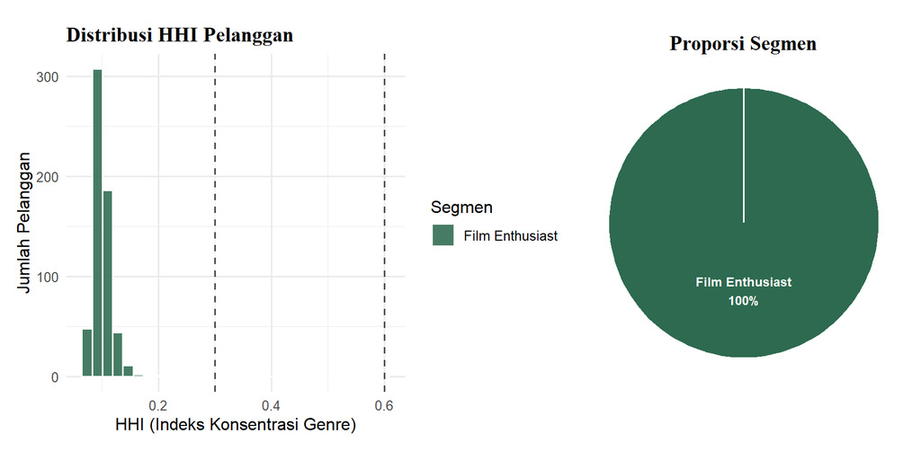

Distribusi nilai HHI pelanggan. Garis putus-putus menunjukkan batas segmen pada 0,3 dan 0,6.

```r
p_hist <- df_hhi %>%
  ggplot(aes(x = hhi, fill = segmen)) +
  geom_histogram(bins = 30, color = "white", alpha = .88) +
  scale_fill_manual(
    values = c("Genre Lover"    = "#c9184a",
               "Mixed Watcher"  = "#f4a261",
               "Film Enthusiast"= "#2d6a4f"),
    name = "Segmen"
  ) +
  geom_vline(xintercept = c(0.3, 0.6), linetype = "dashed",
             color = "grey30", linewidth = .6) +
  labs(title = "Distribusi HHI Pelanggan",
       x     = "HHI (Indeks Konsentrasi Genre)",
       y     = "Jumlah Pelanggan") +
  theme_minimal(base_size = 12) +
  theme(plot.title = element_text(face = "bold", family = "serif"))

p_segmen <- df_hhi %>%
  count(segmen) %>%
  mutate(pct   = n / sum(n),
         label = paste0(segmen, "\n", scales::percent(pct, accuracy = 1))) %>%
  ggplot(aes(x = "", y = n, fill = segmen)) +
  geom_col(width = 1, color = "white") +
  coord_polar("y") +
  scale_fill_manual(values = c("Genre Lover"    = "#c9184a",
                               "Mixed Watcher"  = "#f4a261",
                               "Film Enthusiast"= "#2d6a4f")) +
  geom_text(aes(label = label), position = position_stack(vjust = .5),
            size = 3.2, color = "white", fontface = "bold") +
  labs(title = "Proporsi Segmen") +
  theme_void(base_size = 12) +
  theme(legend.position = "none",
        plot.title = element_text(face = "bold", family = "serif", hjust = .5))

p_hist + p_segmen
```

### 3.3.4 Revenue per Segmen

```r
df_payment_total <- dbGetQuery(con, "
  SELECT r.customer_id, SUM(p.amount) AS total_spend
  FROM rental r
    JOIN payment p ON r.rental_id = p.rental_id
  GROUP BY r.customer_id
")

df_segmen_revenue <- df_hhi %>%
  left_join(df_payment_total, by = "customer_id")

df_segmen_revenue %>%
  group_by(segmen) %>%
  summarise(
    n_pelanggan   = n(),
    avg_hhi       = round(mean(hhi), 3),
    avg_rental    = round(mean(total_rental), 1),
    avg_spend     = round(mean(total_spend), 2),
    total_revenue = round(sum(total_spend), 2),
    .groups       = "drop"
  ) %>%
  arrange(desc(total_revenue)) %>%
  kbl(
    caption   = "Perbandingan revenue dan perilaku sewa antar segmen pelanggan",
    col.names = c("Segmen", "Jml. Pelanggan", "Rata-rata HHI",
                  "Rata-rata Rental", "Avg Spend (\\$)", "Total Revenue ($)"),
    align     = c("l","r","r","r","r","r")
  ) %>%
  kable_styling(bootstrap_options = c("striped","hover","condensed"),
                full_width = TRUE) %>%
  row_spec(0, background = "#2d6a4f", color = "white") %>%
  row_spec(1, background = "#d8f3dc")
```

Perbandingan revenue dan perilaku sewa antar segmen pelanggan

| Segmen | Jml. Pelanggan | Rata-rata HHI | Rata-rata Rental | Avg Spend ($) | Total Revenue ($) |
| --- | --- | --- | --- | --- | --- |
| Film Enthusiast | 599 | 0.1 | 26.8 | 112.53 | 67406.56 |

### 3.3.5 Interpretasi

#### 👥 Temuan Utama — Segmentasi Pelanggan

Hasil segmentasi mengungkap temuan yang *luar biasa sekaligus konsisten*: **seluruh 599 pelanggan (100%)** tergolong sebagai **Film Enthusiast**, tidak ada satu pun yang masuk kategori Mixed Watcher atau Genre Lover.

Dengan rata-rata HHI sebesar **0,10** yang mendekati nilai teoritis minimum \(\frac{1}{16} \approx 0,0625\) untuk distribusi seragam sempurna, para pelanggan menyewa film secara sangat merata di semua 16 genre. Ini menunjukkan bahwa perilaku penyewaan di toko ini bersifat *eksplorasi lintas genre*, bukan konsumsi berbasis preferensi sempit.

Secara bisnis: seluruh revenue sebesar **$67.406,56** berasal dari segmen Film Enthusiast, dengan rata-rata pengeluaran **$112,53** per pelanggan dan rata-rata **26,8 rental** per orang.

# 4 Sintesis: Menghubungkan Ketiga Dimensi

## 4.1 Apakah Genre Profit = Genre Populer?

```r
cor_val <- cor(df_genre$total_rental, df_genre$total_revenue, method = "pearson")
```

Korelasi Pearson antara volume rental dan total revenue per genre: **r = 0.849**

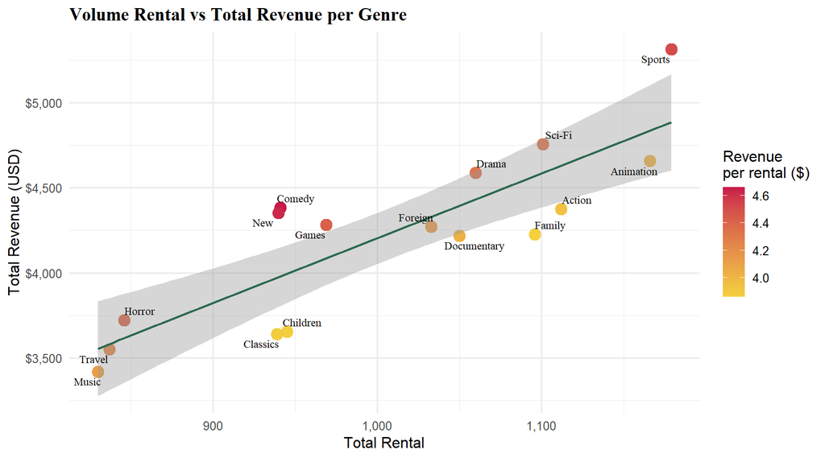

Scatter plot volume sewa vs revenue per genre. Titik di atas garis regresi = genre efisien; di bawah garis = kurang efisien.

```r
df_genre %>%
  ggplot(aes(x = total_rental, y = total_revenue, label = genre)) +
  geom_point(aes(color = revenue_per_rental), size = 4) +
  geom_smooth(method = "lm", se = TRUE, color = "#2d6a4f", linewidth = .8) +
  geom_text_repel(size = 3, max.overlaps = 14, family = "serif") +
  scale_color_gradient(low  = "#f4d03f", high = "#c9184a",
                       name = "Revenue\nper rental ($)") +
  scale_x_continuous(labels = comma) +
  scale_y_continuous(labels = dollar_format(prefix = "$")) +
  labs(title = "Volume Rental vs Total Revenue per Genre",
       x = "Total Rental", y = "Total Revenue (USD)") +
  theme_minimal(base_size = 12) +
  theme(plot.title = element_text(face = "bold", family = "serif"))
```

**Interpretasi Scatter Plot**  
Nilai **r = 0,849** mengonfirmasi hubungan positif yang *kuat* antara volume sewa dan revenue namun tidak sempurna. **Sports** adalah outlier positif terbesar: volume dan revenue sama-sama tertinggi. **Comedy** dan **New** berada di *atas* garis tren (efisien), sementara **Documentary**, **Classics**, dan **Children** berada di *bawah* garis (volume relatif tinggi namun revenue lebih rendah dari prediksi).

# 5 Kesimpulan

**💡 Implikasi Bisnis**

- **Prioritaskan stok genre Sports dan Comedy** — keduanya unggul dalam revenue dengan efisiensi terbaik. Perluas koleksi genre *New* untuk memanfaatkan efisiensinya yang tinggi.
- **Jadikan GINA DEGENERES sebagai highlight katalog** — film yang dibintanginya adalah penggerak volume terbesar dan layak diprioritaskan dalam tampilan rekomendasi utama.
- **Terapkan strategi rekomendasi lintas genre** — karena semua pelanggan adalah Film Enthusiast, program loyalitas berbasis eksplorasi ("sewa 5 genre berbeda, dapat diskon") berpotensi lebih efektif dibanding segmentasi ketat.

# 6 Penutup

Laporan dibuat menggunakan **R Markdown** | Data: **MySQL Sakila Database** | **HAFIIDH EKA SAGITA — M0724030 — Kelas G — Universitas Sebelas Maret**